# Análisis Exploratorio de Datos (EDA) y Preparación K-Means

Análisis Comercial UN Comtrade

## Contexto y Alcance de los Datos

En el presente análisis utiliza información oficial proveniente del repositorio **UN Comtrade** (*United Nations International Trade Statistics Database*), gestionado por la División de Estadística de las Naciones Unidas. Esta base de datos es el estándar global para el registro y monitoreo del comercio internacional de mercancías entre países. El presente análisis será acotado a México como país que reporta, así como a productos con código de 2 dígitos conservando movimientos de importación y exportación.

El análisis se acota a México (código M49: 484), considerando tanto movimientos de importación como de exportación durante el periodo 2015-2025. Los productos se estudian a nivel de Capítulo del Sistema Armonizado (HS a 2 dígitos) y los flujos se desglosan por país socio comercial.

### ¿Qué representa esta información a grandes rasgos?

A nivel macro, el conjunto de datos extraído documenta el **flujo comercial anual de bienes (importaciones y exportaciones)** hacia el país reportante (México, código M49: `484`) durante el periodo **2015-2025**, desglosado por producto y país socio comercial.

Cada registro en este *dataset* captura tres dimensiones fundamentales del intercambio comercial:

1. **Estructura Mercantil (¿Qué se comercia?):** Identificado mediante el código del **Sistema Armonizado (HS)** de clasificación arancelaria. En este estudio, los productos se agregan a nivel de **Capítulo (HS a 2 dígitos)** para evaluar los sectores económicos de procedencia.
2. **Socio comercial (¿con quién se comercia?):** Representado por el código del país socio o proveedor (`partnerCode`), permitiendo rastrear la procedencia geográfica de las mercancías.
3. **Magnitud Económica (¿Cuánto se comercia?):** Expresado a través del valor comercial oficial en dólares estadounidenses (`primaryValue` / `fobvalue`), que mide el volumen financiero del intercambio.

### Propósito del Análisis

El propósito general de este análisis es comprender la evolución de la estructura comercial de México entre 2015 y 2025, utilizando las importaciones y exportaciones como contexto general y profundizando en las importaciones para analizar la importancia económica de los distintos capítulos HS2, la composición de sus países proveedores y los cambios en su nivel de concentración.

A partir de este propósito se plantean las siguientes preguntas que guían el análisis:

- ¿Cómo han evolucionado las importaciones y exportaciones de México entre 2015 y 2025 y cuáles han sido los principales socios a lo largo del periodo?
- ¿Cómo ha evolucionado la concentración de proveedores de los distintos capítulos HS2 entre 2015 y 2025?
- ¿Cómo ha cambiado la importancia económica de los distintos capítulos HS2 dentro de las importaciones mexicanas durante el periodo analizado?
- ¿Es posible identificar grupos de capítulos HS2 con perfiles similares de importancia económica y concentración de proveedores, considerando tanto sus niveles como los cambios observados entre el inicio y el final del periodo?

### Preparación de la información

Descargamos datos anuales de UN Comtrade sobre el comercio de bienes reportado por México entre 2015 y 2025. La consulta incluye importaciones (M) y exportaciones (X), todos los países socios disponibles y productos clasificados por capítulo HS de dos dígitos. La descarga se hizo en dos bloques, 2015–2019 y 2020–2025, y se guarda en un .rds para no repetirla cada vez que se ejecuta el Rmd.

Aunque la consulta fue diseñada para obtener información a nivel HS2 y por país socio, se aplicaron controles adicionales de integridad antes de realizar cualquier agregación monetaria. En particular, se verificó lo siguiente:

- **cmdCode contenga 2 dígitos:**: se conservaron únicamente códigos HS de dos dígitos (nchar(cmdCode) == 2) y se excluyó el agregado general TOTAL `nchar(cmdCode) == 2`
- **Sin totales mundiales:** se excluyó el agregado mundial (partnerCode != 0) para trabajar con países socios individualmente identificados.
- **Sin desgloses secundarios:** se conservaron únicamente registros sin un desglose adicional de segundo socio `partner2Code == 0`
- **Modo de transportes:**cuando se encuentra disponible, se conserva únicamente el agregado correspondiente al total de modos de transporte `motCode == 0`
- **Valor comercial:** se conservaron registros con primaryValue disponible y mayor que cero.

```
## Registros originales: 93,942
```

```
## Registros limpios a nivel Capítulo HS2: 93,942
```

```
## Periodo temporal en la base limpia: 2015 - 2025
```

```
## Valores NAs en la variable de valor monetario: 0
```

### Diccionario de datos seleccionados

La base contiene 93,942 registros y 13 variables. Cada registro representa el valor comercial de una combinación de año, flujo, país socio y capítulo HS2.

PrimaryValue contiene el valor en USD corrientes, mientras que val_musd expresa ese mismo valor en millones de USD.

| Variable | Tipo | Descripción | Uso en el análisis |
| --- | --- | --- | --- |
| `period` | Texto | Año de referencia, por ejemplo `"2015"`. | Identificar el periodo original. |
| `reporterCode` | Entero | Código M49 del país que reporta; `484` corresponde a México. | Verificar el alcance geográfico. |
| `partnerCode` | Entero | Código M49 del país socio. | Identificar proveedores y destinos; |
| `partnerDesc` | Texto | Nombre del país socio. | Etiquetas en tablas y gráficas. |
| `cmdCode` | Texto | Código del capítulo HS de dos dígitos, por ejemplo `"01"`. | Identificar el capítulo sin perder ceros iniciales. |
| `cmdDesc` | Texto | Descripción del capítulo HS2. | Interpretar las categorías de mercancías representadas por cada capítulo. |
| `primaryValue` | Numérico | Valor comercial registrado en USD corrientes. | Calcular totales, participaciones e índices de concentración. |
| `fobvalue` | Numérico | Valor FOB en USD, cuando está disponible. | Revisar la información de valoración; no se suma a `primaryValue`. |
| `flow_code` | Texto | Dirección del flujo: `M` para importación y `X` para exportación. | Separar los dos tipos de comercio. |
| `flow_desc` | Texto | Descripción del flujo: `Import` o `Export`. | Etiquetas legibles en tablas y gráficas. |
| `año` | Entero | Año numérico obtenido de `period`. | Construir series y comparaciones anuales. |
| `hs2` | Texto | Código HS2 derivado de `cmdCode`; en esta extracción coinciden. | Agrupar el comercio por capítulo y definir la unidad de análisis del modelo K-Means. |
| `val_musd` | Numérico | `primaryValue / 1,000,000`, en millones de USD. | Presentar valores en una escala legible. |

**Unidad de observación:** año × flujo × país socio × capítulo HS2. La combinación `año + flow_code + partnerCode + hs2` debe revisarse para detectar duplicados.

### Análisis de variables clave

Para comenzar a caracterizar la estructura comercial de México, se busca responder la primera pregunta del análisis:

**¿Cómo han evolucionado las importaciones y exportaciones de México entre 2015 y 2025 y cuáles han sido los principales socios y capítulos HS2 a lo largo del periodo?**

En primer lugar, se analiza la evolución anual del valor de las importaciones y exportaciones para identificar la trayectoria general del comercio mexicano durante el periodo estudiado.

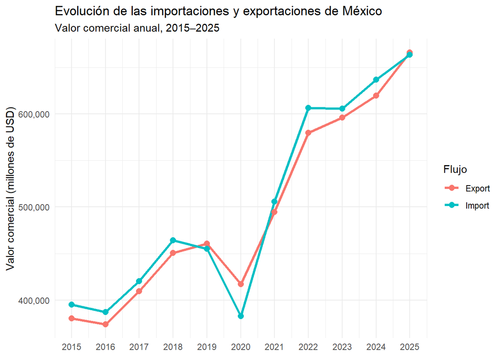

A partir de la gráfica se observa una tendencia general de crecimiento del valor nominal entre 2015 y 2025, aunque no de forma continua. En 2020 se presenta una disminución tanto en importaciones como en exportaciones respecto de 2019, coincidiendo con el periodo de disrupciones internacionales asociado a la pandemia de COVID-19. A partir de 2021 ambos flujos muestran una recuperación y alcanzan sus mayores valores hacia el final del periodo.

Dado que los valores están expresados en USD corrientes, este comportamiento describe la evolución del valor monetario reportado y no debe interpretarse directamente como crecimiento del volumen físico comerciado.

El siguiente paso consiste en analizar los principales socios del comercio mexicano.

**Principales socios comerciales**

Las siguientes tablas muestran los cinco principales socios de México en exportaciones e importaciones de acuerdo con el valor comercial acumulado nominal durante el periodo analizado.

*IMPORTACIONES*

```
## # A tibble: 5 × 3
##   partnerDesc   total_valor_M_usd porcentaje
##   <chr>         <chr>             <chr>
## 1 USA           2,415,479         43.7%
## 2 China         1,050,837         19.0%
## 3 Rep. of Korea 200,044           3.6%
## 4 Japan         197,230           3.6%
## 5 Germany       191,401           3.5%
```

*EXPORTACIONES*

```
## # A tibble: 5 × 3
##   partnerDesc                            total_valor_M_usd porcentaje
##   <chr>                                  <chr>             <chr>
## 1 USA                                    4,349,854         79.8%
## 2 Canada                                 158,277           2.9%
## 3 China                                  87,066            1.6%
## 4 Germany                                74,722            1.4%
## 5 North America and Central America, nes 61,706            1.1%
```

Los resultados permiten identificar a los países que concentraron los mayores valores comerciales acumulados durante 2015–2025. En particular, Estados Unidos ocupa una posición predominante tanto como destino de las exportaciones mexicanas como entre los proveedores de las importaciones.

Veamos si a lo largo del tiempo estos 5 socios han cambiado.

**Evolución de la participación de los principales socios**

*IMPORTACIONES*

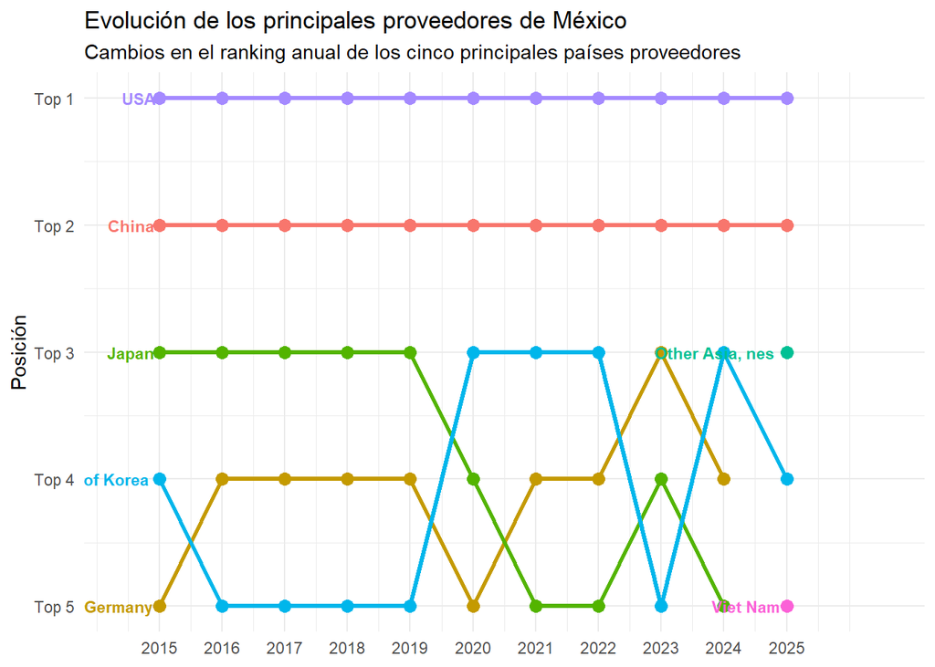

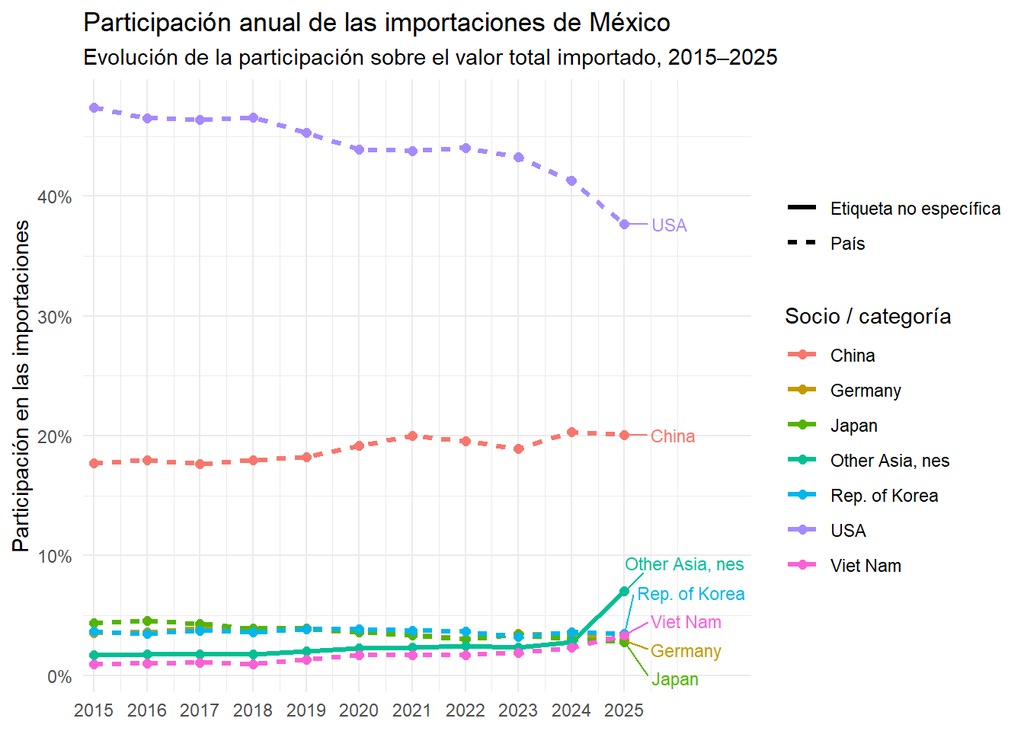

Las dos visualizaciones muestran que la estructura de los principales proveedores de México Estados Unidos se mantiene como el principal proveedor durante todo el periodo 2015–2025 y China conserva el segundo lugar. No obstante, la participación de Estados Unidos disminuye gradualmente, mientras que la de China permanece relativamente estable e incluso aumenta ligeramente hacia los últimos años.

A partir del tercer lugar se observa una mayor rotación. Japón, República de Corea y Alemania intercambian posiciones durante buena parte del periodo, mientras que hacia los años más recientes aparecen nuevos cambios en la composición de los principales proveedores. En particular, en 2025 destaca el incremento de Other Asia, nes y la presencia de Viet Nam entre los proveedores de mayor participación.

El aumento reciente de la participación de proveedores asiáticos podría estar relacionado con una reconfiguración de las cadenas de suministro internacionales posterior a las tensiones comerciales entre Estados Unidos y China. En particular, los aranceles aplicados a productos chinos desde 2018 y las medidas posteriores sobre sectores tecnológicos pudieron generar incentivos para diversificar proveedores y relocalizar etapas de producción hacia México y otros países asiáticos.

*EXPORTACIONES*

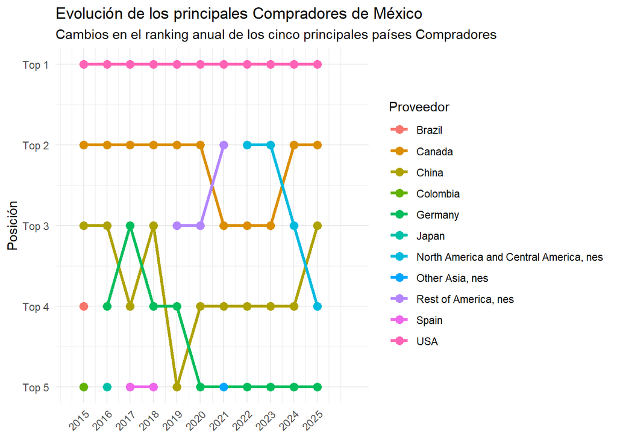

[figure not shown]

En las exportaciones se observa que Estados Unidos se mantiene en la primera posición durante todo el periodo 2015–2025 y concentra una proporción ampliamente superior a la del resto de los compradores.A partir de la segunda posición existe una mayor movilidad.

El análisis muestra diferencias entre la estructura de las importaciones y exportaciones. Sin embargo, esta visión puede ocultar comportamientos distintos entre categorías de productos. Un capítulo HS2 puede concentrar gran parte de su comercio en un solo socio, mientras que otro puede distribuirlo entre numerosos países.

Por ello, el siguiente paso consiste en medir la concentración de socios dentro de cada capítulo HS2 y para cada año, con especial atención a las importaciones, que constituyen el foco principal del análisis.

Para cada año, flujo y capítulo, la participación del socio es $p_i = valor_i / \sum_j valor_j$. El índice de Herfindahl–Hirschman es $HHI = \sum_i p_i^2$. Cercano a 1 implica mayor concentración de **valor**; el número efectivo de socios es $1/HHI$. `top1` mide la cuota del socio principal. Los socios sin valor positivo observado no se imputan como cero.Adicionalmente, se calcula participacion, que representa el peso de cada capítulo HS2 dentro del valor total del flujo comercial correspondiente a cada año

**- ¿Cómo ha evolucionado la concentración de proveedores de los distintos capítulos HS2 entre 2015 y 2025?**

El análisis muestra diferencias entre la estructura de las importaciones . Sin embargo, esta visión puede ocultar comportamientos distintos entre categorías de productos. Un capítulo HS2 puede concentrar gran parte de su comercio en un solo socio, mientras que otro puede distribuirlo entre numerosos países.

Por ello, el siguiente paso consiste en medir la concentración de socios dentro de cada capítulo HS2 y para cada año, con especial atención a las importaciones, que constituyen el foco principal del análisis.

Para cada año, flujo y capítulo, la participación del socio es $p_i = valor_i / \sum_j valor_j$. El índice de Herfindahl–Hirschman es $HHI = \sum_i p_i^2$. Cercano a 1 implica mayor concentración de **valor**; el número efectivo de socios es $1/HHI$. `top1` mide la cuota del socio principal. Los socios sin valor positivo observado no se imputan como cero.Adicionalmente, se calcula participacion, que representa el peso de cada capítulo HS2 dentro del valor total del flujo comercial correspondiente a cada año

Como primera aproximación, se examinan los capítulos de importación con mayor concentración en 2025. Esta comparación permite identificar qué categorías presentan valores elevados de HHI y determinar si dicha concentración corresponde además a capítulos de importancia económica relevante.

Diez capítulos HS2 con mayor concentración de proveedores en 2025

| HS2 | Capítulo | Valor (M USD) | Núm. de socios | HHI | Proveedor principal (%) | Proveedor principal |
| --- | --- | --- | --- | --- | --- | --- |
| 67 | Feathers and down, prepared; and articles made of feather or of down; artificial flowers; articles of human hair | 92.9 | 15 | 0.917 | 95.7 | China |
| 27 | Mineral fuels, mineral oils and products of their distillation; bituminous substances; mineral waxes | 36,996.2 | 38 | 0.870 | 93.3 | USA |
| 10 | Cereals | 8,179.9 | 16 | 0.805 | 89.6 | USA |
| 66 | Umbrellas, sun umbrellas, walking-sticks, seat sticks, whips, riding crops; and parts thereof | 57.6 | 13 | 0.743 | 85.6 | China |
| 23 | Food industries, residues and wastes thereof; prepared animal fodder | 2,400.1 | 23 | 0.741 | 85.9 | USA |
| 04 | Dairy produce; birds’ eggs; natural honey; edible products of animal origin, not elsewhere specified or included | 3,149.4 | 18 | 0.678 | 81.9 | USA |
| 17 | Sugars and sugar confectionery | 1,333.0 | 32 | 0.666 | 80.9 | USA |
| 50 | Silk | 7.2 | 7 | 0.606 | 74.4 | China |
| 05 | Animal originated products; not elsewhere specified or included | 368.2 | 12 | 0.570 | 74.3 | USA |
| 21 | Miscellaneous edible preparations | 2,694.6 | 50 | 0.564 | 74.8 | USA |

### Hallazgos principales: concentración de importaciones en 2025

- **Combustibles y aceites minerales (HS2 `27`) combinan valor elevado y alta concentración:** México importó aproximadamente **37,000 millones de USD** y **93.3%** del valor provino de USA.
- **Cereales (HS2 `10`) muestran un patrón similar:** el valor importado fue de aproximadamente **8,180 millones de USD**, con **89.6%** procedente de USA.
- **Plumas y artículos relacionados (HS2 `67`) tienen el HHI más alto**, pero su valor importado fue mucho menor (**92.9 millones de USD**). Por ello, la concentración debe interpretarse junto con la importancia económica del capítulo.
- **Contar países no basta para medir diversificación:** en preparaciones alimenticias diversas (HS2 `21`) aparecen **50 socios**, pero USA concentra **74.8%** del valor.

Entre los capítulos mostrados, `27` y `10` destacan por combinar valores importados elevados con una fuerte concentración en un socio. Estos resultados describen el **valor comercial registrado en 2025**; por sí solos no miden cantidades físicas ni riesgo de desabasto.

Diez capítulos HS2 con mayor concentración de proveedores en 2015

| HS2 | Capítulo | Valor (M USD) | Núm. de socios | HHI | Proveedor principal (%) | Proveedor principal |
| --- | --- | --- | --- | --- | --- | --- |
| 23 | Food industries, residues and wastes thereof; prepared animal fodder | 1,623.3 | 23 | 0.870 | 93.2 | USA |
| 66 | Umbrellas, sun umbrellas, walking-sticks, seat sticks, whips, riding crops; and parts thereof | 46.5 | 24 | 0.808 | 89.6 | China |
| 17 | Sugars and sugar confectionery | 807.0 | 48 | 0.790 | 88.8 | USA |
| 05 | Animal originated products; not elsewhere specified or included | 274.1 | 20 | 0.763 | 86.9 | USA |
| 10 | Cereals | 4,005.4 | 20 | 0.758 | 86.8 | USA |
| 27 | Mineral fuels, mineral oils and products of their distillation; bituminous substances; mineral waxes | 26,455.5 | 58 | 0.715 | 84.2 | USA |
| 67 | Feathers and down, prepared; and articles made of feather or of down; artificial flowers; articles of human hair | 45.8 | 24 | 0.695 | 83.0 | China |
| 21 | Miscellaneous edible preparations | 1,324.1 | 57 | 0.693 | 83.1 | USA |
| 86 | Railway, tramway locomotives, rolling-stock and parts thereof; railway or tramway track fixtures and fittings and parts thereof; mechanical (including electro-mechanical) traffic signalling equipment … | 1,464.8 | 32 | 0.692 | 82.7 | USA |
| 02 | Meat and edible meat offal | 3,820.5 | 14 | 0.691 | 82.5 | USA |

### Hallazgos relevantes: concentración de importaciones en 2015

- **Combustibles minerales (HS2 `27`) combinó valor elevado y concentración:** México importó aproximadamente **26,456 millones de USD** y **84.2%** del valor provino de USA. Fue el capítulo de mayor valor entre los diez con HHI más alto.
- **Residuos de la industria alimentaria y forraje (HS2 `23`) fue el más concentrado de los diez:** registró un HHI de **0.870** y USA aportó **93.2%** de los aproximadamente **1,623 millones de USD** importados.
- **Un número alto de socios no garantiza que el valor esté repartido:** en preparaciones alimenticias diversas (HS2 `21`) aparecen **57 países**, pero USA concentró **83.1%** del valor.
- **USA fue el socio principal en ocho de los diez capítulos** con mayor HHI. China fue el socio principal en los capítulos `66` y `67`, que también mostraron alta concentración, aunque con valores importados mucho menores.

Veamos su cambio de 2015 a 2025

Capítulos con mayor aumento en la concentración de proveedores entre 2015 y 2025

| HS2 | Capítulo | HHI 2015 | HHI 2025 | Cambio HHI | Top 1 2015 (%) | Top 1 2025 (%) | Cambio Top 1 (pp) | Proveedor 2015 | Proveedor 2025 |
| --- | --- | --- | --- | --- | --- | --- | --- | --- | --- |
| 50 | Silk | 0.193 | 0.606 | 0.413 | 31.0 | 74.4 | 43.3 | China | China |
| 14 | Vegetable plaiting materials; vegetable products not elsewhere specified or included | 0.190 | 0.469 | 0.280 | 26.9 | 66.4 | 39.6 | Peru | Sri Lanka |
| 93 | Arms and ammunition; parts and accessories thereof | 0.156 | 0.394 | 0.238 | 27.6 | 55.0 | 27.4 | USA | Areas, nes |
| 67 | Feathers and down, prepared; and articles made of feather or of down; artificial flowers; articles of human hair | 0.695 | 0.917 | 0.222 | 83.0 | 95.7 | 12.7 | China | China |
| 89 | Ships, boats and floating structures | 0.294 | 0.508 | 0.214 | 46.9 | 67.3 | 20.4 | Spain | USA |
| 26 | Ores, slag and ash | 0.219 | 0.430 | 0.211 | 42.4 | 61.1 | 18.7 | USA | USA |
| 91 | Clocks and watches and parts thereof | 0.364 | 0.550 | 0.186 | 45.5 | 72.4 | 27.0 | Switzerland | Switzerland |
| 27 | Mineral fuels, mineral oils and products of their distillation; bituminous substances; mineral waxes | 0.715 | 0.870 | 0.156 | 84.2 | 93.3 | 9.1 | USA | USA |
| 75 | Nickel and articles thereof | 0.315 | 0.451 | 0.136 | 53.3 | 66.4 | 13.0 | USA | USA |
| 53 | Vegetable textile fibres; paper yarn and woven fabrics of paper yarn | 0.183 | 0.294 | 0.111 | 35.0 | 51.1 | 16.1 | Sri Lanka | China |

Al comparar 2015 con 2025 se observa que el aumento de la concentración de proveedores no ocurrió de la misma manera en todos los capítulos. En algunos casos, el proveedor principal se mantuvo sin cambios pero incrementó considerablemente su participación. Por ejemplo, en seda (HS50) China pasó de concentrar 31.0% a 74.4% del valor importado, mientras que el HHI aumentó de 0.193 a 0.606.

En otros capítulos, el aumento de la concentración estuvo acompañado por un cambio en el proveedor principal. En materias vegetales para trenzar (HS14) el liderazgo pasó de Perú a Sri Lanka y la participación del principal proveedor aumentó de 26.9% a 66.4%.

En conjunto, estos resultados muestran que el incremento del HHI puede responder tanto al fortalecimiento de un proveedor que ya era dominante como a una reconfiguración del proveedor principal.

*Ahora cuales se diversificaron*

Capítulos con mayor reducción en la concentración de proveedores entre 2015 y 2025

| HS2 | Capítulo | HHI 2015 | HHI 2025 | Cambio HHI | Top 1 2015 (%) | Top 1 2025 (%) | Cambio Top 1 (pp) | Proveedor 2015 | Proveedor 2025 |
| --- | --- | --- | --- | --- | --- | --- | --- | --- | --- |
| 59 | Textile fabrics; impregnated, coated, covered or laminated; textile articles of a kind suitable for industrial use | 0.595 | 0.274 | -0.321 | 76.6 | 48.5 | -28.0 | USA | USA |
| 57 | Carpets and other textile floor coverings | 0.536 | 0.241 | -0.295 | 72.4 | 42.2 | -30.1 | USA | USA |
| 56 | Wadding, felt and nonwovens, special yarns; twine, cordage, ropes and cables and articles thereof | 0.579 | 0.328 | -0.251 | 75.6 | 53.7 | -22.0 | USA | USA |
| 71 | Natural, cultured pearls; precious, semi-precious stones; precious metals, metals clad with precious metal, and articles thereof; imitation jewellery; coin | 0.396 | 0.153 | -0.244 | 61.4 | 29.9 | -31.5 | USA | USA |
| 79 | Zinc and articles thereof | 0.493 | 0.263 | -0.231 | 67.7 | 39.1 | -28.6 | USA | USA |
| 02 | Meat and edible meat offal | 0.691 | 0.479 | -0.212 | 82.5 | 65.9 | -16.5 | USA | USA |
| 11 | Products of the milling industry; malt, starches, inulin, wheat gluten | 0.599 | 0.387 | -0.212 | 76.4 | 60.0 | -16.3 | USA | USA |
| 37 | Photographic or cinematographic goods | 0.471 | 0.260 | -0.211 | 67.1 | 45.7 | -21.4 | USA | USA |
| 95 | Toys, games and sports requisites; parts and accessories thereof | 0.552 | 0.349 | -0.203 | 73.4 | 56.0 | -17.4 | China | China |
| 05 | Animal originated products; not elsewhere specified or included | 0.763 | 0.570 | -0.193 | 86.9 | 74.3 | -12.6 | USA | USA |

Entre los capítulos que más redujeron su concentración entre 2015 y 2025 se observa un patrón consistente: en la mayoría de los casos el proveedor principal se mantiene sin cambios, pero su participación disminuye de forma importante. Esto sugiere que la diversificación ocurrió principalmente por una redistribución del valor importado hacia otros proveedores, más que por un reemplazo del país líder.

Por ejemplo, en tejidos textiles impregnados o recubiertos (HS59) Estados Unidos continuó siendo el principal proveedor, pero su participación cayó de 76.6% a 48.5%, mientras que el HHI disminuyó de 0.595 a 0.274.

En conjunto, el análisis muestra que la concentración de proveedores no evolucionó de manera uniforme entre los distintos capítulos HS2. Algunos capítulos aumentaron claramente su dependencia de pocos proveedores. En otros casos ocurrió el proceso contrario: el HHI disminuyó y la participación del proveedor principal se redujo, reflejando una distribución más equilibrada del valor entre distintos socios.

Por lo tanto, para evaluar la estructura de proveedores no basta con identificar al socio principal o contar el número de países participantes. Es necesario considerar conjuntamente el HHI, la participación del proveedor dominante y los cambios de estas medidas a lo largo del tiempo.

Un capítulo altamente concentrado no necesariamente representa una parte importante de las importaciones mexicanas. El siguiente paso consiste en incorporar la importancia económica de cada capítulo para distinguir entre casos de alta concentración pero bajo peso comercial y aquellos que combinan concentración elevada con una participación relevante dentro de las importaciones.

**- ¿Cómo ha cambiado la importancia económica de los distintos capítulos HS2 dentro de las importaciones mexicanas durante el periodo analizado?**

Después de analizar cómo ha cambiado la concentración de proveedores, el siguiente paso consiste en evaluar la importancia económica de los distintos capítulos HS2 dentro de las importaciones mexicanas.

Principales capítulos HS2 exportados de México hacia Estados Unidos, 2015–2025

| Código HS2 | Producto | Valor (M USD) |
| --- | --- | --- |
| 87 | Vehicles; other than railway or tramway rolling stock, and parts and accessories thereof | 1,110,594.5 |
| 85 | Electrical machinery and equipment and parts thereof; sound recorders and reproducers; television image and sound recorders and reproducers, parts and accessories of such articles | 860,008.1 |
| 84 | Nuclear reactors, boilers, machinery and mechanical appliances; parts thereof | 439,763.5 |
| 84 | Machinery and mechanical appliances, boilers, nuclear reactors; parts thereof | 414,395.2 |
| 90 | Optical, photographic, cinematographic, measuring, checking, medical or surgical instruments and apparatus; parts and accessories | 219,553.4 |

Principales capítulos HS2 importados por México desde Estados Unidos, 2015–2025

| Código HS2 | Producto | Valor (M USD) |
| --- | --- | --- |
| 27 | Mineral fuels, mineral oils and products of their distillation; bituminous substances; mineral waxes | 389,696.1 |
| 85 | Electrical machinery and equipment and parts thereof; sound recorders and reproducers; television image and sound recorders and reproducers, parts and accessories of such articles | 252,271.8 |
| 87 | Vehicles; other than railway or tramway rolling stock, and parts and accessories thereof | 230,997.0 |
| 39 | Plastics and articles thereof | 189,237.4 |
| 84 | Nuclear reactors, boilers, machinery and mechanical appliances; parts thereof | 186,704.7 |

Notamos que con USA las categorías que se tienen en común tanto de exportación como de importación son Vehículos, maquinaria eléctrica y categoría 84 correspondiente a reactores nucleares, bolers, maquinaria y partes para estos.

*Exportaciones*

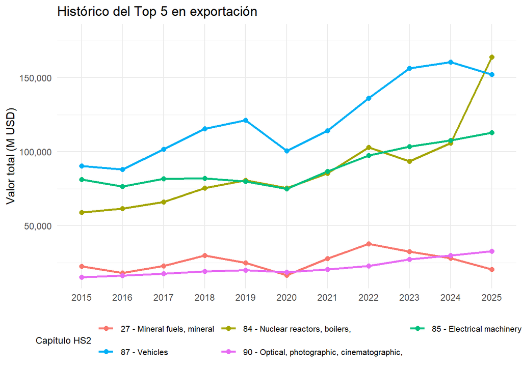

Los cinco capítulos de mayor valor exportado acumulado presentan trayectorias distintas durante 2015–2025. Vehículos (HS87) mantiene el mayor valor exportado durante la mayor parte del periodo y muestra una tendencia general creciente, aunque con una caída visible en 2020 y una ligera reducción en 2025. Maquinaria mecánica (HS84) y maquinaria eléctrica (HS85) también muestran una tendencia ascendente, destacando el fuerte incremento de HS84 hacia 2025.

*Importaciones*

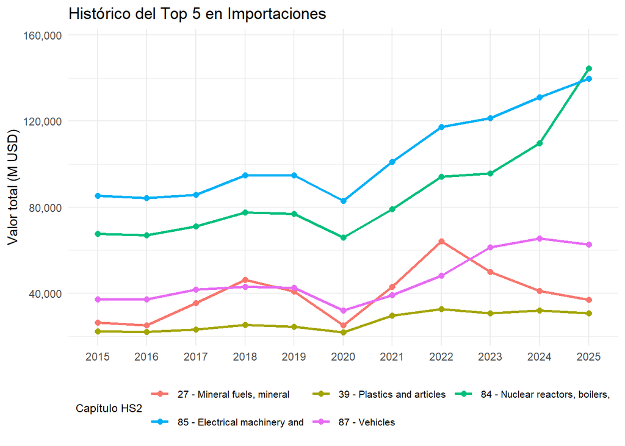

Los principales capítulos de importación presentan diferencias importantes tanto en su magnitud como en su evolución durante el periodo. Maquinaria eléctrica (HS85) y maquinaria mecánica (HS84) concentran los mayores valores importados, mientras que vehículos (HS87), combustibles minerales (HS27) y plásticos (HS39) muestran trayectorias menores.

Al igual que en las exportaciones, en 2020 se observa una caída en varios de los principales capítulos, seguida de una recuperación posterior. Sin embargo, dado que los valores están expresados en USD corrientes, estas variaciones representan cambios en el valor monetario importado y no necesariamente cambios equivalentes en las cantidades físicas comerciadas.

El análisis exploratorio muestra que los capítulos HS2 no evolucionan de manera homogénea. Algunos mantienen una participación elevada dentro de las importaciones, otros ganan o pierden importancia a lo largo del periodo y, al mismo tiempo, presentan distintos niveles y cambios en la concentración de sus proveedores. Analizar cada capítulo de manera individual permite identificar casos particulares, pero dificulta reconocer patrones comunes entre el conjunto de categorías. Por ello, se utiliza un modelo de agrupamiento K-Means con el objetivo de identificar capítulos HS2 que presenten perfiles similares.

## Pregunta de investigación y alcance del modelo

**Pregunta principal:** ¿Es posible identificar grupos de capítulos HS2 con perfiles similares de importancia económica y concentración de proveedores, considerando tanto sus niveles como los cambios observados entre el inicio y el final del periodo?

**Hipótesis descriptiva:** la concentración no cambia de la misma manera en todos los capítulos, algunos de alto valor se concentran más y otros se diversifican. Se describen asociaciones, sin atribuir los cambios a una causa concreta.

La **unidad del EDA** es año × flujo × capítulo HS2 y, cuando se estudian cuotas, socio comercial. El EDA conserva las etiquetas originales; el modelo utiliza únicamente el valor asignado a socios geográficos identificados. La **unidad de K-means** será el capítulo HS2: cada capítulo tendrá indicadores resumidos de concentración, cambio y participación importadora. No existe una etiqueta futura a predecir; el HHI es el indicador principal que queremos comprender y los grupos son perfiles descriptivos. Las exportaciones se conservan como contexto de la relación comercial de México, mientras que el modelo se enfoca en proveedores de importaciones.

### 1. Cobertura y calidad antes de comparar años

El número de capítulos, socios y registros por año permite detectar descargas incompletas. Revisar especialmente 2025 antes de interpretar cambios. Un país o capítulo sin valor positivo registrado no se imputa automáticamente como cero.

```r
calidad_adicional <- tibble(
  registros_origen = nrow(df_comercio),
  registros_limpios = nrow(df_clean),
  valor_faltante_origen = sum(is.na(df_comercio$primaryValue)),
  valor_no_positivo_origen = sum(!is.na(df_comercio$primaryValue) &
                                   df_comercio$primaryValue <= 0),
  duplicados_exactos_origen = sum(duplicated(df_comercio))
)
knitr::kable(calidad_adicional, caption = "Auditoría básica de calidad")
```

Auditoría básica de calidad

| registros_origen | registros_limpios | valor_faltante_origen | valor_no_positivo_origen | duplicados_exactos_origen |
| --- | --- | --- | --- | --- |
| 93942 | 93942 | 0 | 0 | 0 |

```r
duplicados_llave <- df_clean %>%
  count(año, flow_code, partnerCode, hs2) %>% filter(n > 1)
cat("Llaves año/flujo/socio/HS2 repetidas:", nrow(duplicados_llave), "\n")
```

```
## Llaves año/flujo/socio/HS2 repetidas: 0
```

```r
# Si hay repetidas, revisar su origen: el chunk de indicadores suma por socio,
# pero dos filas idénticas o distintos desgloses podrían duplicar valor.

cobertura_adicional <- df_clean %>% group_by(año, flow_code) %>%
  summarise(registros = n(), capitulos_hs2 = n_distinct(hs2),
            socios = n_distinct(partnerCode),
            valor_mmusd = sum(primaryValue) / 1e9, .groups = "drop")
knitr::kable(cobertura_adicional, digits = 1,
             caption = "Cobertura por año y flujo (valor en miles de millones de USD)")
```

Cobertura por año y flujo (valor en miles de millones de USD)

| año | flow_code | registros | capitulos_hs2 | socios | valor_mmusd |
| --- | --- | --- | --- | --- | --- |
| 2015 | M | 5112 | 97 | 207 | 395.3 |
| 2015 | X | 4260 | 97 | 142 | 380.6 |
| 2016 | M | 5177 | 97 | 201 | 387.1 |
| 2016 | X | 4258 | 97 | 145 | 374.0 |
| 2017 | M | 5191 | 97 | 210 | 420.4 |
| 2017 | X | 4325 | 97 | 157 | 409.4 |
| 2018 | M | 5288 | 97 | 206 | 464.3 |
| 2018 | X | 4374 | 97 | 153 | 450.7 |
| 2019 | M | 5257 | 97 | 211 | 455.2 |
| 2019 | X | 4378 | 97 | 163 | 460.6 |
| 2020 | M | 5077 | 97 | 206 | 383.0 |
| 2020 | X | 4179 | 97 | 154 | 417.0 |
| 2021 | M | 4165 | 97 | 216 | 505.7 |
| 2021 | X | 3314 | 97 | 141 | 494.5 |
| 2022 | M | 4171 | 97 | 216 | 606.3 |
| 2022 | X | 3237 | 97 | 135 | 579.8 |
| 2023 | M | 4212 | 97 | 216 | 605.6 |
| 2023 | X | 3226 | 97 | 137 | 596.0 |
| 2024 | M | 4185 | 97 | 220 | 636.8 |
| 2024 | X | 3170 | 97 | 136 | 619.7 |
| 2025 | M | 4172 | 97 | 218 | 663.6 |
| 2025 | X | 3214 | 97 | 136 | 665.9 |

```r
faltan_periodos <- tidyr::expand_grid(año = 2015:2025,
                                     flow_code = c("M", "X")) %>%
  anti_join(cobertura_adicional, by = c("año", "flow_code"))
if (nrow(faltan_periodos))
  warning("Faltan combinaciones de año y flujo; revisar la descarga.")
```

Aparecen 97 capítulos HS2 en ambos flujos durante todos los años de 2015 a 2025. En particular, 2025 tiene cifras de cobertura parecidas a 2024: importaciones con 4,172 frente a 4,185 registros y exportaciones con 3,214 frente a 3,170. Esto hace razonable incluir 2025 en las comparaciones, aunque el conteo por sí solo no confirma que sus valores sean definitivos.

| flow_code | hs2 | socios_2020 | socios_2021 | cambio_socios | valor_musd_2020 | valor_musd_2021 |
| --- | --- | --- | --- | --- | --- | --- |
| M | 84 | 160 | 115 | -45 | 65845.5 | 79159.5 |
| M | 85 | 191 | 146 | -45 | 82866.8 | 101171.7 |
| M | 73 | 136 | 98 | -38 | 8220.7 | 11061.1 |
| M | 39 | 133 | 105 | -28 | 21865.5 | 29738.8 |
| M | 97 | 38 | 14 | -24 | 33.3 | 21.7 |
| M | 61 | 96 | 73 | -23 | 1755.5 | 2599.2 |
| M | 82 | 92 | 71 | -21 | 1976.8 | 2453.6 |
| M | 62 | 91 | 72 | -19 | 1281.7 | 1632.6 |
| M | 09 | 46 | 29 | -17 | 287.8 | 395.7 |
| M | 17 | 48 | 31 | -17 | 760.3 | 782.5 |
| X | 48 | 81 | 56 | -25 | 1729.0 | 1880.3 |
| X | 85 | 132 | 108 | -24 | 74946.3 | 86724.1 |
| X | 84 | 132 | 110 | -22 | 75449.0 | 85299.6 |
| X | 49 | 71 | 50 | -21 | 331.6 | 392.2 |
| X | 73 | 104 | 83 | -21 | 6164.2 | 8101.3 |
| X | 63 | 65 | 46 | -19 | 1462.8 | 1614.8 |
| X | 87 | 111 | 92 | -19 | 100692.6 | 114306.7 |
| X | 38 | 80 | 63 | -17 | 1321.9 | 1447.0 |
| X | 96 | 67 | 50 | -17 | 1133.7 | 1417.1 |
| X | 34 | 72 | 56 | -16 | 1054.2 | 1191.0 |

La tabla reúne los 10 capítulos HS2 con mayor caída en el número de socios de cada flujo. Es una selección de top de capítulos, así que no representa por sí sola el cambio de todo el comercio de México.

El hallazgo más interesante es que menos socios no significa necesariamente menos comercio: * En importaciones, HS84 pasó de 160 a 115 socios (−45), mientras su valor subió de 65,845.5 a 79,159.5 millones de USD (+20.2 %). * También en importaciones, HS85 perdió 45 socios (191 a 146), pero su valor aumentó de 82,866.8 a 101,171.7 millones (+22.1 %). * En exportaciones, HS87 pasó de 111 a 92 socios (−19), mientras su valor creció de 100,692.6 a 114,306.7 millones (+13.5 %). * HS97 en importaciones es una excepción dentro de la selección: bajaron tanto los socios (38 a 14) como el valor (33.3 a 21.7 millones).